# Introduction to Communication Systems

## Analog and Digital Communication

Radio waves can be artificially generated, and they propagate through free space. The natural response to this discovery is to explore whether we can manipulate these waves to enable useful applications. In the case of communication, we would like to encode information onto these radio waves in some manner. For example: turning the radio wave on and off is a way by which we can signal a change in state. As you might have guessed, there must be much more efficient ways to encode information onto radio waves, and there are. By manipulating the amplitude and phase of radio waves in a deterministic manner, we can map complicated messages onto a radio wave at the transmitter and reliably decode the message at the receiver. This technique of mapping a message signal onto a radio wave is broadly referred to as **modulation**.

While we have been mostly concerned with radio waves, the concepts discussed in this module apply generally to any communication technique using waves that propogate in a medium (like sound waves in the sea). Wireless communication majorly deals with smartly engineering transceiver systems that operate in a given wireless channel (the medium that the radio wave propogates in).

There are two major classes in wireless communication: analog and digital. The initial use of wireless communication was to send speech and audio signals over long distances. One can understand intuitively that these signals represent some useful information. These are *message signals* that we want to use our communication system to convey. All signals in nature are continuous time signals, i.e they are *analog* in nature. Even if voice is recorded in a digital storage medium like a hard drive, it is still consumed as an analog signal through the speaker. Radio waves (electromagnetic waves) are also analog in nature.

```python
%matplotlib inline
import numpy as np
import matplotlib.pyplot as plt
from scipy import signal
```

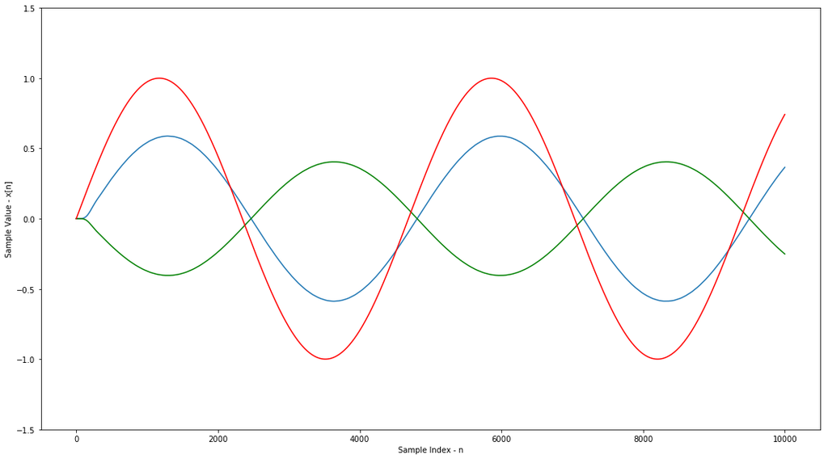

```python
t = np.arange(0,1,0.0001); # Sampling time instants
x_c = np.sin(2*np.pi*100*t);
x_c_2 = np.sin(2*np.pi*100*t+0.3*np.pi);
x_d = np.cos(2*np.pi*100*t+0.3*np.pi);
x = np.sin(2*np.pi*2.1332*t);

x_p = x*x_c
x_b_q = x_p*x_c_2
x_b_i = x_p*x_d

b, a = signal.butter(6, 0.01, btype='low', analog = False);

x_b_i = signal.lfilter(b,a,x_b_i);
x_b_q = signal.lfilter(b,a,x_b_q);

fig=plt.figure(figsize=(18, 10), dpi= 80, facecolor='w', edgecolor='k')
plt.plot(2*x_b_q)
plt.plot(x_b_i,'g')
plt.plot(x,'r')
plt.xlabel('Sample Index - n')
plt.ylabel('Sample Value - x[n]')
plt.ylim([-1.5,1.5]);

plt.show()
```